# Prosper Loan Data Analysis

## by Justin Olgui

## Investigation Overview

The objective of this presentation is to demonstrate some important relationship that influence APR.

## Dataset Overview

This dataset contains data from over 100,000 prosper loans. Each row contains information about a specific loan that was funded through the Prosper marketplace.

#### Who is prosper?

Prosper is a San Francisco based company in the peer-to-peer lending marketplace in the United States. Since 2005, Prosper has facilitated more than $15 billion in loans to more than 930,000 people.

#### What is peer2peer lending?

For those who are not familiar, Prosper does not actually lend money, they essentially provide a marketplace for lenders and borrowers to meet, think online dating for loans. As a prospective borrower, you would go through the process of filling out an application, why do you want money, how much do you make, are you employed and so on. They will then assign you a Prosperscore and put your loan up on their marketplace at which point lenders who are looking for higher rate investment returns can choose to fund a portion, or the entirety of your loan. Some of the information on our borrower includes but is not limited to APR, Employment status, credit rating, term, occupation, etc.

## APR

Before we introduce other variables I believe it's important to look at APR an isolation to understand what might be considered normal. APR is almost normally distributed, however it does have a slight right skew. With a large amount of loans in the 0.35 - 0.375 range. Our average borrower on Prosper is paying 21.96%

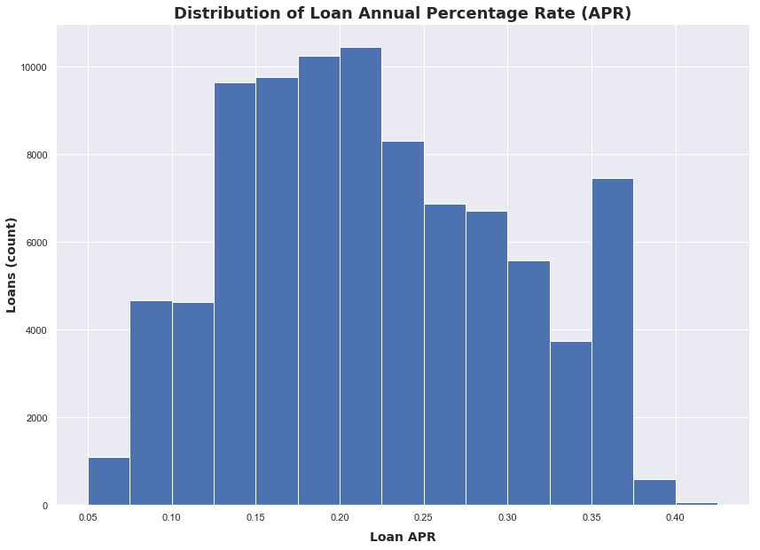

```python
#Dictionary to alter font
t_font = {'family' : 'normal',
        'weight' : 'bold',
        'size'   : 18}
l_font ={'family' : 'normal',
        'weight' : 'bold',
        'size'   : 14}

# Using Hist to plot our distribution for APR
sb.set(style="darkgrid")
bins = np.arange(0.05, 0.45, 0.025)
plt.figure(figsize=(14, 10))
plt.hist(data = df, x = 'BorrowerAPR', bins=bins)
plt.title('Distribution of Loan Annual Percentage Rate (APR)', fontdict=t_font)
plt.xlabel('Loan APR', fontdict=l_font, labelpad=10)
plt.ylabel('Loans (count)', fontdict=l_font, labelpad=2);
```

## Borrower APR by Category

If we think of APR as a proxy to sentiment of inherent risk as viewed by our investors, our box plot demonstrates personal loans to be the lest risky based on median 17.6%, Cosmetic Procedure seems to be the one that carries the highest risk with a median of 27.2%

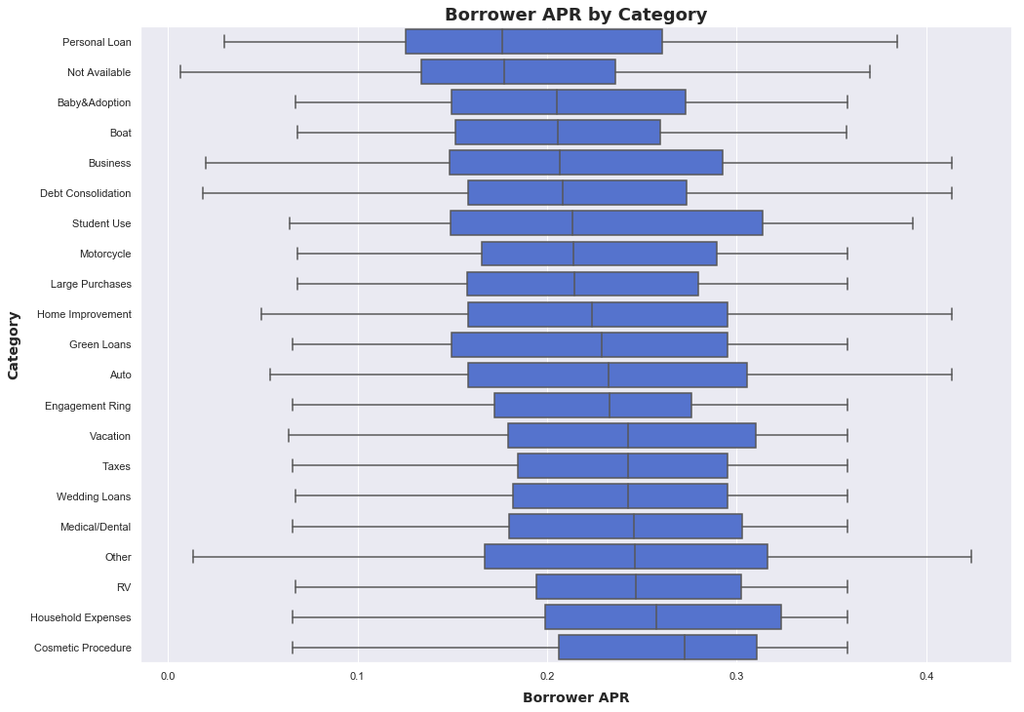

```python
# Groupby Listing Category and return the median
listingCat_median_APR = df.groupby('ListingCategory', as_index=False)['BorrowerAPR'].median()
# Sort by Borrower APR
listingCat_median_APR_val = listingCat_median_APR.sort_values(by='BorrowerAPR')
listingCat_median_APR = list(listingCat_median_APR_val['ListingCategory'])
#Create boxplot
ax = sb.boxplot(data = df, x = 'BorrowerAPR', y = 'ListingCategory', color="royalblue", order=listingCat_median_APR);
plt.gcf().set_size_inches(16, 12);
plt.title('Borrower APR by Category', fontdict=t_font);
plt.xlabel('Borrower APR',fontdict=l_font, labelpad=10)
plt.ylabel('Category',fontdict=l_font, labelpad=10);
```

## Risk Models Over Time

Credit Score and Prosper Score have the strongest negative correlation of all variables -49.9% for the former and -66.8% for the latter. Said another way as your score of either proprietary model increases as the expectancy that your APR will drop increases. Here are some key insights:

### Credit Score Impact on APR Over Time

- Best rates (below 10%) are reserved for the best Credit scores (800+)
- Post 2008 Prosper increased their credit score requirement, the yellow dots have disappeared
- 2011 onwards max APR has dropped from above 40% to slightly above 36%
- 2011 onwards number of borrowers with 800+ credit rating is trending downwards

### Prosper Score Impact on APR Over Time

- Best rates (below 10%) are reserved for the best Prosper Scores (10+)
- Appetite for risk has increased over time
- 2013 - 2014 Prosper Score follows a gradual transition from purple to yellow, investors seemed to have really adopted this risk rating
- 2011 onwards max APR has dropped from above 40% to slightly above 36%

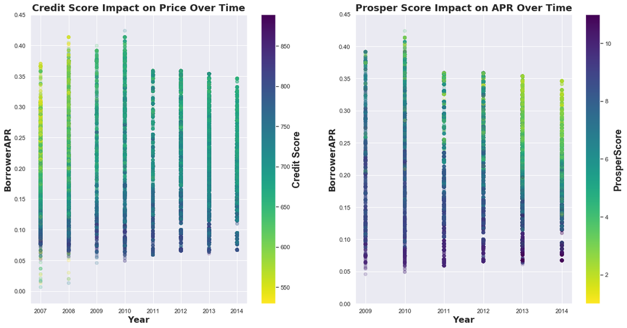

```python
#Dictionary to alter font
t_font = {'family' : 'normal',
        'weight' : 'bold',
        'size'   : 18}
l_font ={'family' : 'normal',
        'weight' : 'bold',
        'size'   : 16}


# Scatter plot to show relationship between Creditscore, ProsperScore and APR
plt.subplot(1, 2, 1)
plt.gcf().set_size_inches(20, 10)
plt.subplots_adjust(wspace=0.3)
plt.scatter(data=df, x='Year', y='BorrowerAPR', c='CreditScoreMean', cmap='viridis_r', alpha=0.2);
cbar = plt.colorbar()
cbar.solids.set(alpha=1)
plt.title('Credit Score Impact on Price Over Time',fontdict=t_font);
plt.xlabel('Year',fontdict=l_font)
plt.ylabel('BorrowerAPR',fontdict=l_font);
plt.yticks(np.arange(0, 0.5, step=0.05));
cbar.set_label(label='Credit Score',size=18,weight='bold');


plt.subplot(1, 2, 2)
plt.gcf().set_size_inches(20, 10)
plt.subplots_adjust(wspace=0.2)
plt.scatter(data=df, x='Year', y='BorrowerAPR', c='ProsperScore', cmap='viridis_r', alpha=0.2);
cbar = plt.colorbar()
cbar.solids.set(alpha=1)
plt.title('Prosper Score Impact on APR Over Time',fontdict=t_font);
plt.xlabel('Year',fontdict=l_font)
plt.ylabel('BorrowerAPR',fontdict=l_font);
plt.yticks(np.arange(0, 0.5, step=0.05));
cbar.set_label(label='ProsperScore',size=18,weight='bold')
```